# 20. Networks

## Page Links

In this chapter we will start by working with network data taken from Wikipedia. Specifically, we took all of the English Wikipedia pages associated with each of the food items in the `foods` dataset. Wikipedia pages contain many internal links between pages; we collected information about each time one of the pages in our dataset provided a link to another page in our collection. We will explore how to do produce this dataset using R code in Chapter 18. Only links within the main body of the text were used.

The resulting dataset contains one row for each detected link. The two variables in the dataset indicate the page the link was found on (`page`) and the name of the page that was linked to. Here is the full dataset:

```r
page_citation <- read_csv(file.path("data", "page_citation.csv"))
page_citation
```

```
## # A tibble: 100 x 2
##    page      link
##    <chr>     <chr>
##  1 Apple     Banana
##  2 Asparagus Onion
##  3 Asparagus Chicken
##  4 Asparagus Shrimp
##  5 Asparagus Beef
##  6 Asparagus Tomato
##  7 Avocado   Pear
##  8 Avocado   Banana
##  9 Avocado   Corn
## 10 Avocado   Lime
## # … with 90 more rows
```

Looking at the top of the dataset, which is arranged by the page name, we see that the Wikipedia page for “Apple” has a link to “Banana” but no other pages. Asparagus, on the other hand, links to five other food items.

We can use grouping and summarizing functions to see how often each page is linked to. Arranging these in order gives some understanding of which pages are more centrally located in our dataset.

```r
page_citation %>%
  group_by(link) %>%
  summarize(sm_count()) %>%
  arrange(desc(count))
```

```
## # A tibble: 48 x 2
##    link   count
##    <chr>  <int>
##  1 Apple      5
##  2 Banana     5
##  3 Lemon      5
##  4 Lime       5
##  5 Potato     5
##  6 Corn       4
##  7 Milk       4
##  8 Orange     4
##  9 Beef       3
## 10 Celery     3
## # … with 38 more rows
```

However, counts can only get us so far. These say nothing, for example, about how easily we can get hop between two pages by following 2, 3, or 4 links. In order to understand the dataset we need a way of visualizing and modelling all of the connections at once. This requires treating the dataset as a network (or graph).

A graph consists of a collection of objects (here, pages) and a collection of edges between those objects (here, internal links). An easy way to describe a network is with an object that looks exactly like our dataset `page_citation`, called an edge list, that describes pairs of objects that are linked together.

The **smodels** package provides an easy way of taking an edge list and returning structured data the allows us to understand the dataset as a network. If we apply the function `sm_graph_layout` to the edge list, an R object containing two elements are returned. Splitting these off requires using the dollar sign notation, as follows, and results in two datasets.

```r
graph <- sm_graph_layout(page_citation)
node <- graph$node
edge <- graph$edge
```

The node dataset contains extracted information about each of the objects in our collection. We will describe each of these, in turn, throughout the remainder of this chapter.

```r
node
```

```
## # A tibble: 54 x 10
##    id            x      y degree  eigen   close between cluster component
##    <chr>     <dbl>  <dbl>  <dbl>  <dbl>   <dbl>   <dbl> <chr>       <int>
##  1 Apple      3.79  0.698      6 0.298  0.00746   98.8  1               1
##  2 Banana     2.98 -0.170      7 0.405  0.00806  121.   1               1
##  3 Asparagus  6.72  1.63       6 0.121  0.00741  349.   1               1
##  4 Onion      5.64  3.62       5 0.0436 0.00637   71.0  3               1
##  5 Chicken    8.21  2.95       2 0.0179 0.00559   46    5               1
##  6 Shrimp     8.54  1.01       2 0.0179 0.00585  210    2               1
##  7 Beef       5.30  2.09       5 0.0797 0.00699   61.2  3               1
##  8 Tomato     5.18  0.147     10 0.339  0.00826  338.   1               1
##  9 Avocado    2.54  0.708      9 0.604  0.00787  227.   1               1
## 10 Pear       2.24 -0.275      3 0.189  0.00637    1.84 1               1
## # … with 44 more rows, and 1 more variable: component_size <dbl>
```

The first column gives a label for the row. In the next two columns, named `x` and `y`, is a computed way to layout the objects in two-dimensions that maximizes linked pages being close to one another while minimizing the amount that all of the nodes are bunched together. There is no exact meaning of the individual variables; rather, its the relationships that they show that are interesting.

Using the first three variables, we can plot the pages as a scatter plot with labels to see what pages appear to be closely related to one another.

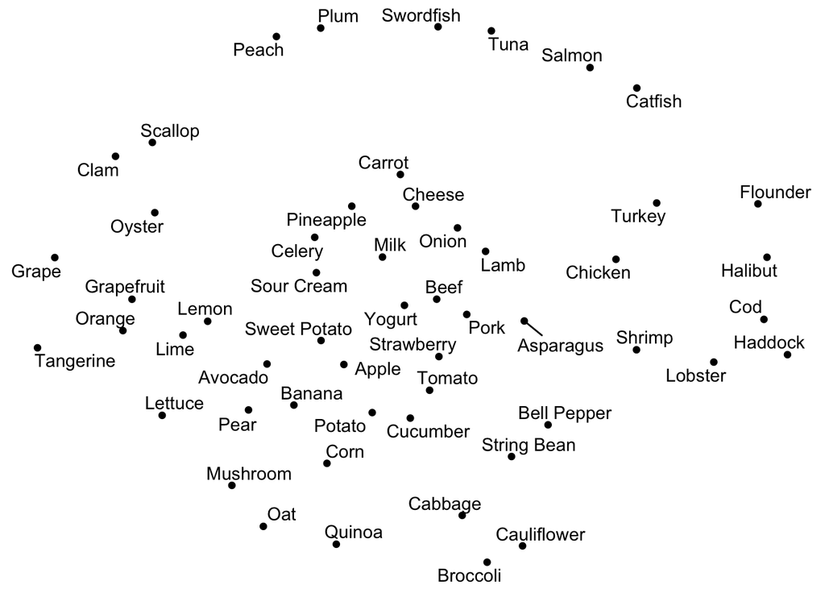

```r
node %>%
  ggplot() +
    geom_point(aes(x = x, y = y)) +
    geom_text_repel(aes(x = x, y = y, label = id)) +
    theme_void()
```

The edge dataset contains one row for each edge in the dataset. The dataset has four columns These describe the `x` and `y` values of one node in the edge and variables `xend` and `yend` to indicate where in the scatterplot the ending point of the edge is.

```r
edge
```

```
## # A tibble: 100 x 4
##        x  xend      y   yend
##    <dbl> <dbl>  <dbl>  <dbl>
##  1  3.79  2.98  0.698 -0.170
##  2  6.72  5.64  1.63   3.62
##  3  6.72  8.21  1.63   2.95
##  4  6.72  8.54  1.63   1.01
##  5  6.72  5.30  1.63   2.09
##  6  6.72  5.18  1.63   0.147
##  7  2.54  2.24  0.708 -0.275
##  8  2.98  2.54 -0.170  0.708
##  9  2.54  3.52  0.708 -1.42
## 10  2.54  1.18  0.708  1.33
## # … with 90 more rows
```

We can add edges into the plot by adding a geom layer of type `geom_segment`. It takes four aesthetics, named exactly the same as in `edge` dataset. The plot gets busy with all of these lines, so we will set the opacity of them lower so as to not cluter the visual space with the connections.

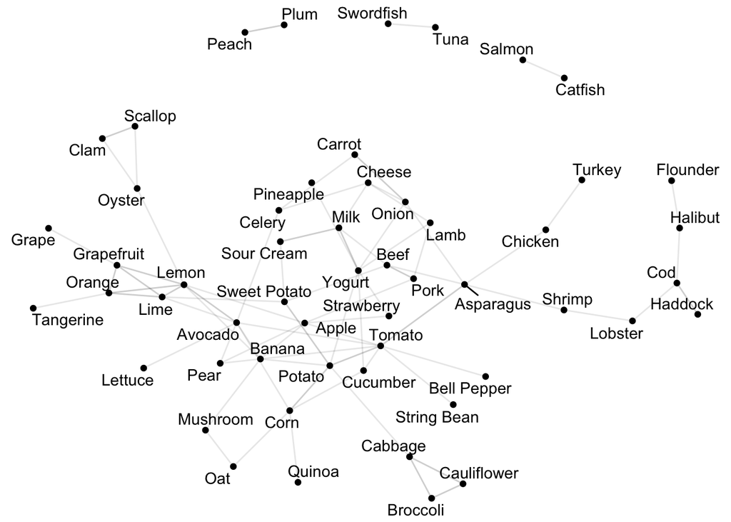

```r
node %>%
  ggplot(aes(x, y)) +
    geom_point() +
    geom_segment(aes(xend = xend, yend = yend), data = edge, alpha = 0.1) +
    geom_text_repel(aes(label = id)) +
    theme_void()
```

We now see the underlying data that describes the plot. Notice that here we are not taking the direction of the links into account. In one of the subsequent sections we will see how to plot the segements as arrows to indicate the direct that the links occur in.

## Network Centrality

One of the core questions that arise when working with network data is trying to identify the relative centrality of each node in the network. Several of the derived measurements in the `nodes` dataset capture various forms of centrality. In this section we will color the network diagram with these measurements and discuss what properties each of them measures.

A component of a network is a collection of all the nodes that can be reached by following along the edges. The `nodes` dataset contains an integer id called `component` describing each of the components in the graph. These are ordered by reverse size, so component 1 will always be the largest (or at least, tied for the largest) component of the graph. Coloring the graph by component reveals four part of the graph; we convert the component variable to a factor to force ggplot to use a categorical scale.

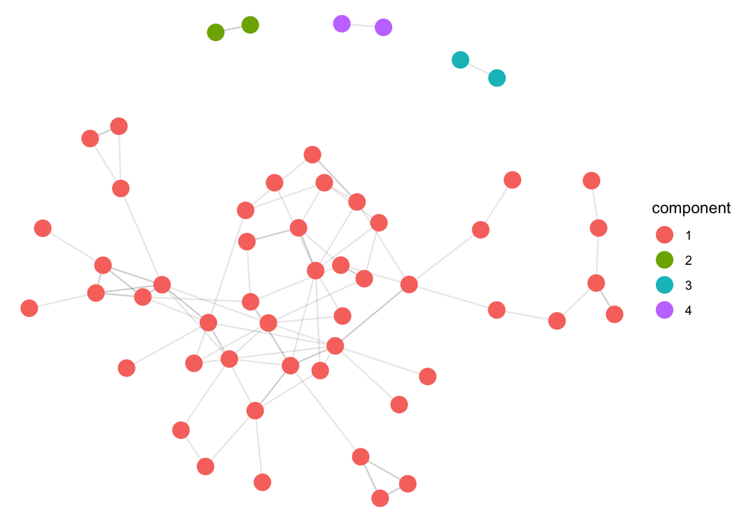

```r
node %>%
  mutate(component = factor(component)) %>%
  ggplot(aes(x, y)) +
    geom_segment(aes(xend = xend, yend = yend), data = edge, alpha = 0.1) +
    geom_point(aes(color = component), size = 5) +
    theme_void()
```

This component number gives a very coarse measurement of how central a node is. We can say that, in some way, all of the nodes in component 1 are more central than the other 6 orphaned pages. Note that having one large component and several small ones is a typical features of many naturally occuring networks.

Another measurement of centrality is a node’s degree. The degree of a node is the number of neighbors it has; in other words, it counts how many edges the node is a part of. The degree of each node has been computed in the `node` table. This is similar to the counts that be produced in the first section by counting occurances in the raw edge list. Ploting degree on our plot shows that the nodes with the highest degree do seem to sit in the middle of the plot and correspond to a high number of having a large number of edges.

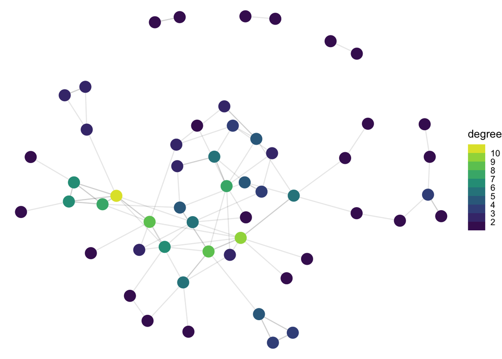

```r
node %>%
  ggplot(aes(x, y)) +
    geom_segment(aes(xend = xend, yend = yend), data = edge, alpha = 0.1) +
    geom_point(aes(color = degree), size = 5) +
    scale_color_binned(type = "viridis", n.breaks = 15) +
    theme_void()
```

As mentioned above, the degree of a node does not take into account anything other than direct neighbors. A more holistic measurement is given by a quantity called the *eigenvalue centrality*, which is provided in the `node` table. This centrality value provides a score for each node that is proportional to the sum of the scores of its neighbors. Mathematically, it assigns a set of scores $s_j$ for each node such that:

$$s_j = \lambda \cdot \sum_{i \in \text{Neighbors{j}}} s_i$$

If you have taken a course in linear algebra and are familiar with the eigenvalues of a matrix, know that the score can be efficently calculated by an eigenvalue equation. If not, just know that it’s a score that takes into account all of the nodes at once. The eigenvalue score is, by convention, scales so that the largest score is 1. It is only possible to describe the eigenvalue centrality scores for a connected set of nodes on a graph, so the computation is done individually for each component. Plotting the scores on the plot shows a slightly different pattern compared to the degree centrality scores.

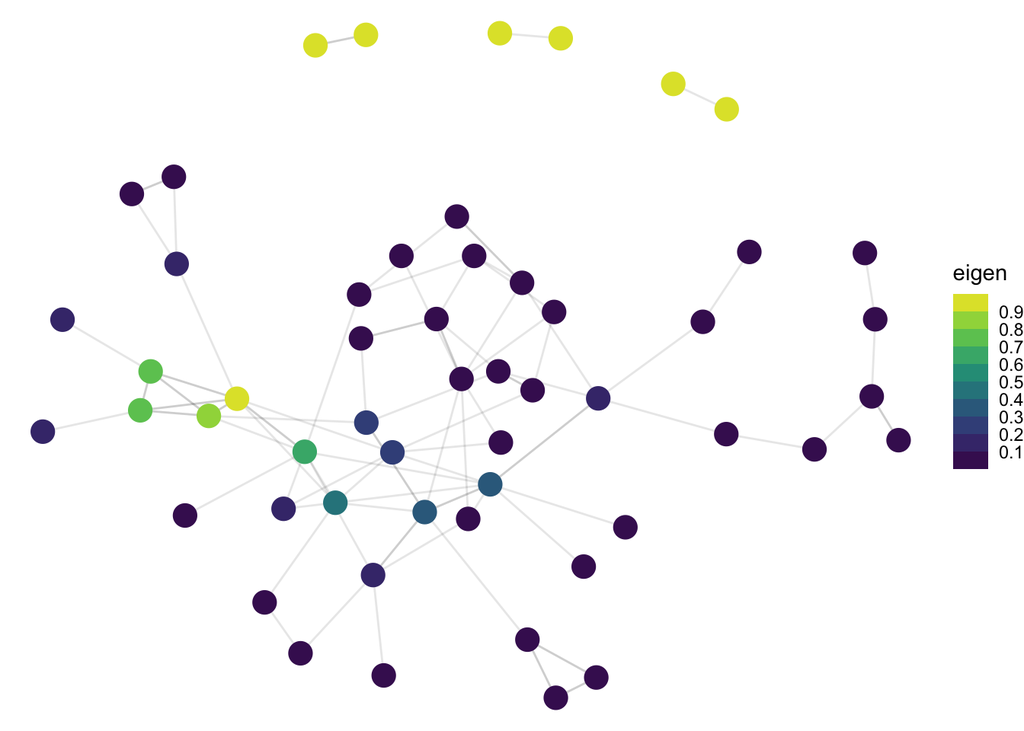

```r
node %>%
  ggplot(aes(x, y)) +
    geom_segment(aes(xend = xend, yend = yend), data = edge, alpha = 0.1) +
    geom_point(aes(color = eigen), size = 5) +
    scale_color_binned(type = "viridis", n.breaks = 15) +
    theme_void()
```

The biggest difference is that the eigenvalue centrality is more concentrated on one set of connections, whereas degree centrality is more spread out.

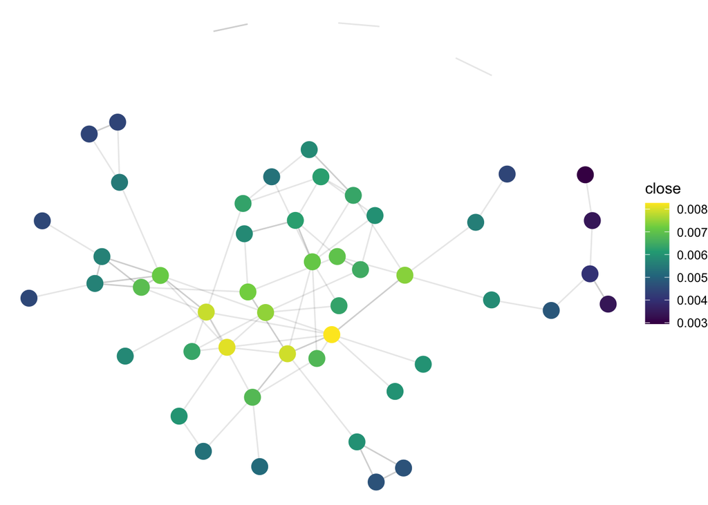

```r
node %>%
  filter(component %in% c(1)) %>%
  ggplot(aes(x, y)) +
    geom_segment(aes(xend = xend, yend = yend), data = edge, alpha = 0.1) +
    geom_point(aes(color = close), size = 5) +
    scale_color_viridis_c() +
    theme_void()
```

Notice that these scores are slightly different than the eigenvalue centrality scores, with the most central node moving from the “Lemon” page to the “Tomato” page.

The final measurement of centrality we have in our table, *betweenness centrality* also comes from considering minimal paths. For every two nodes in a connected component, consider all of the possible ways to go from one to the other along edges in the graph. Then, consider all of the paths (there may be only one) between the two nodes that require a minimal number of hops. The betweenness centrality scores measures how many of these minimal paths go through each node (there is some normalization to account for the case when there are many minimal paths, so the counts are not exact integers). This score is stored in the variable `between`.

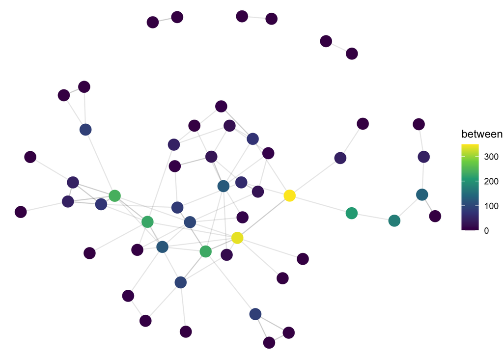

```r
node %>%
  ggplot(aes(x, y)) +
    geom_segment(aes(xend = xend, yend = yend), data = edge, alpha = 0.1) +
    geom_point(aes(color = between), size = 5) +
    scale_color_viridis_c() +
    theme_void()
```

The betweeness score here, as is often the case, tends to be have a different pattern than the other centrality scores. It gives a high score to bridges between different parts of the network, rather than giving high weight to how central a node is within a particular cluster. In the next section we will see that this is a useful property for understanding the structure of a network.

## Centrality Applications

While it is instructive to color the graph plots above with the centrality scores, most applications of graph centrality focus on studying the `node` table directly to understand the structure created by a set of relationships. For example, we could sort the node table by component and eigenvalue scores to get a sense of what pages are the most central to the graph. Here, for example, we see that the eigenvalue centrality is largest for the citrus fruits (“Lemon”, “Lime”, “Grapefruit”, and “Orange”):

```r
node %>%
  arrange(component, desc(eigen))
```

```
## # A tibble: 54 x 10
##    id               x      y degree eigen   close between cluster component
##    <chr>        <dbl>  <dbl>  <dbl> <dbl>   <dbl>   <dbl> <chr>       <int>
##  1 Lemon        1.58   1.62      11 1     0.00714   240.  4               1
##  2 Lime         1.18   1.33       8 0.862 0.00690    74.9 4               1
##  3 Orange       0.205  1.42       7 0.781 0.00565    46   4               1
##  4 Grapefruit   0.352  2.09       7 0.781 0.00565    46   4               1
##  5 Avocado      2.54   0.708      9 0.604 0.00787   227.  1               1
##  6 Banana       2.98  -0.170      7 0.405 0.00806   121.  1               1
##  7 Tomato       5.18   0.147     10 0.339 0.00826   338.  1               1
##  8 Potato       4.25  -0.331      9 0.303 0.00794   231.  1               1
##  9 Apple        3.79   0.698      6 0.298 0.00746    98.8 1               1
## 10 Sweet Potato 3.42   1.21       5 0.231 0.00725    81.9 1               1
## # … with 44 more rows, and 1 more variable: component_size <dbl>
```

Looking at a two-way relationship, we can dig deeper into the way that the graph is structured. For example, take a plot of the eigenvalue and betweeness scores for the pages:

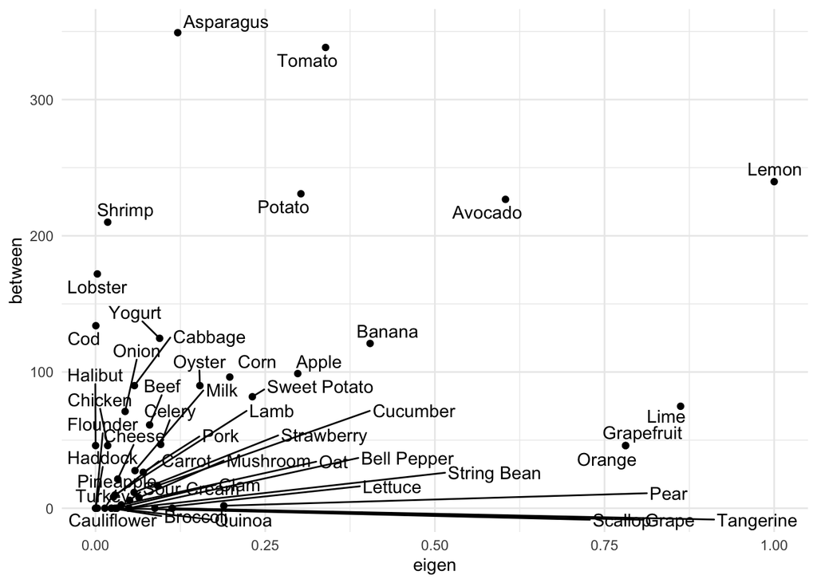

```r
node %>%
  filter(component %in% c(1)) %>%
  ggplot() +
    geom_point(aes(x = eigen, y = between)) +
    geom_text_repel(aes(x = eigen, y = between, label = id))
```

The pages with a high betweeness score but relatively low eigenvalue score (“Asparagus”, “Shrimp”, “Potato”, “Tomato”, “Lobster”) indicate pages that links different parts of the graph together. Tomato is often thought of as sitting inbetween fruits and vegetables, for example. The Asparagus happens to mention that it is frequently “stir-fried with chicken, shrimp, or beef”, causing it to be a gatekeeper between vegetables and the meats.

Plotting eigenvalue centrality and closeness reveals additional patterns in the dataset.

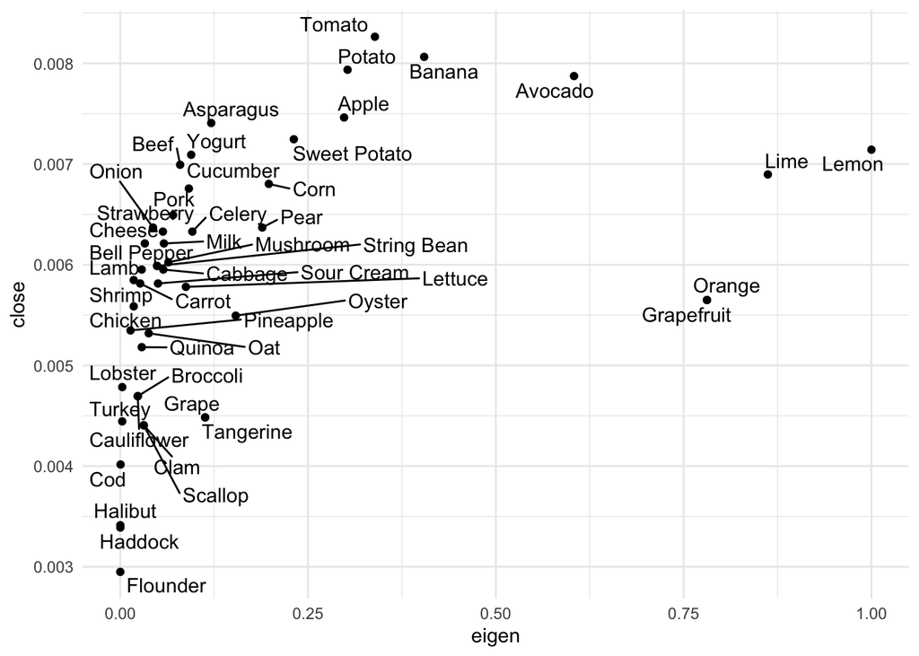

```r
node %>%
  filter(component %in% c(1)) %>%
  ggplot() +
    geom_point(aes(x = eigen, y = close)) +
    geom_text_repel(aes(x = eigen, y = close, label = id))
```

As seen in the layout plots, this graph shows that the citrus fruits have very high eigenvalue scores but only modest closeness. Nodes that have high closeness scores but modest eigenvalue scores include “Beef” and “Yogurt”, which are central to their only clusters of the meats and diary products, respectively.

## Network Clusters

Another algorithm that we can perform on a graph is that of clustering. Here, we try to split the nodes into groups such that a large number of the edges are between nodes within a group rather than across groups. Here is a visualization of the clusters detected on our graph:

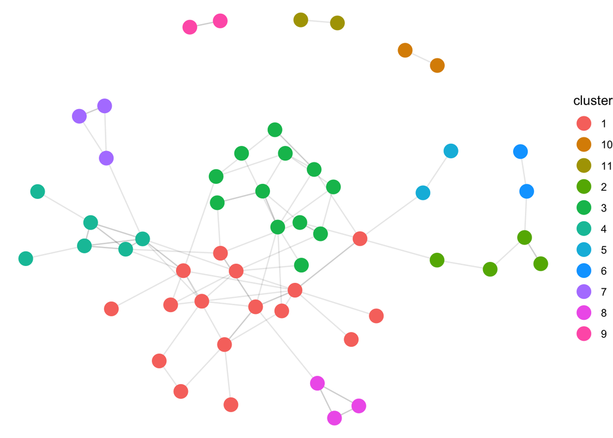

```r
node %>%
  ggplot(aes(x, y)) +
    geom_segment(aes(xend = xend, yend = yend), data = edge, alpha = 0.1) +
    geom_point(aes(color = cluster), size = 5) +
    theme_void()
```

We can paste together the nodes within a cluster to try to further understand the internal structure of the relationships.

```r
node %>%
  filter(component %in% 1) %>%
  group_by(cluster) %>%
  summarize(sm_paste(id)) %>%
  select(id_paste)
```

```
## # A tibble: 8 x 1
##   id_paste
##   <fct>
## 1 Apple; Banana; Asparagus; Tomato; Avocado; Pear; Corn; Lettuce; Potato; Mushr…
## 2 Shrimp; Cod; Haddock; Lobster
## 3 Onion; Beef; Celery; Pork; Milk; Carrot; Cheese; Lamb; Yogurt; Sour Cream; St…
## 4 Lime; Lemon; Grapefruit; Orange; Grape; Tangerine
## 5 Chicken; Turkey
## 6 Halibut; Flounder
## 7 Clam; Oyster; Scallop
## 8 Broccoli; Cabbage; Cauliflower
```

## Directed Networks

At the start of the chapter, we noted that our graph assumed that edges did not have a direction. It is possible to compute graph metrics that take this relationship into account by setting the `directed` argument of `sm_graph_layout` to `TRUE`.

```r
graph <- sm_graph_layout(page_citation, directed = TRUE)
node <- graph$node
edge <- graph$edge
```

The `node` table contains a slightly different set of measurements. Closeness centrality is no longer available; eigenvalue centrality is still computed, but is done so without using the directions of the edges. There are now three different degree counts: the out-degree (number of links on the page) the in-degree (number of links into a page), and the total of these two.

```r
node
```

```
## # A tibble: 54 x 11
##    id              x      y degree_out degree_in degree_total  eigen between
##    <chr>       <dbl>  <dbl>      <dbl>     <dbl>        <dbl>  <dbl>   <dbl>
##  1 Apple      3.07    2.11           1         5            6 0.298     64.3
##  2 Banana     4.02    2.11           2         5            7 0.405    329.
##  3 Asparagus  1.23   -1.04           5         1            6 0.121    126.
##  4 Onion     -0.338   0.918          2         3            5 0.0436    95.8
##  5 Chicken    0.0172 -2.42           1         1            2 0.0179    31
##  6 Shrimp     1.65   -3.10           1         1            2 0.0179    31
##  7 Beef       1.60    0.192          2         3            5 0.0797    43
##  8 Tomato     2.96    0.244          8         2           10 0.339    350.
##  9 Avocado    3.69    2.54           7         2            9 0.604    116.
## 10 Pear       3.27    3.40           2         1            3 0.189      0.5
## # … with 44 more rows, and 3 more variables: cluster <chr>, component <int>,
## #   component_size <dbl>
```

To visualize the directed graph, we add an `arrow` argument to the `geom_segement` layer. This shows, for example, that “Peach” and “Plum” both link to each other whereas “Salmon” links to “Catfish”, but not vice-versa.

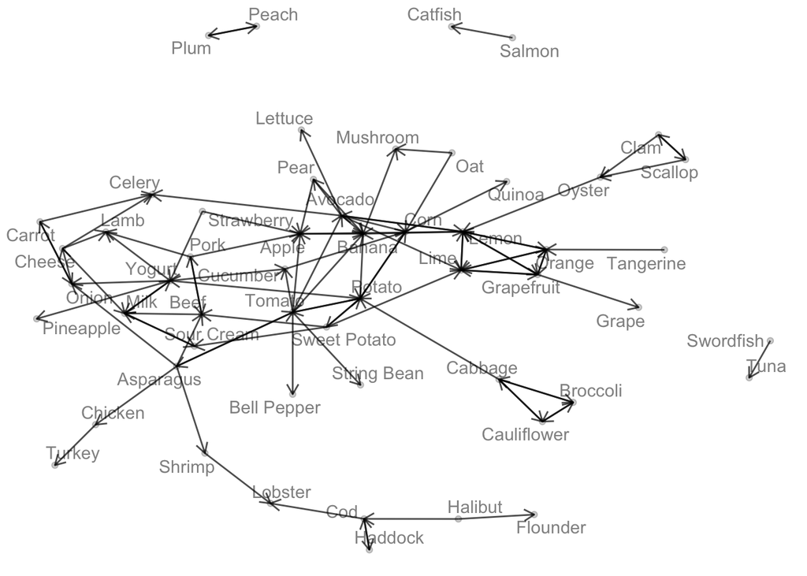

```r
node %>%
  ggplot(aes(x, y)) +
    geom_point(alpha = 0.2) +
    geom_text_repel(aes(label = id), alpha = 0.5) +
    geom_segment(
      aes(xend = xend, yend = yend),
      data = edge,
      alpha = 0.7,
      arrow = arrow(length = unit(0.02, "npc"))
    ) +
    theme_void()
```

An interesting plot with the data from the directed graph is to show the in-degree as a function of the out-degree.

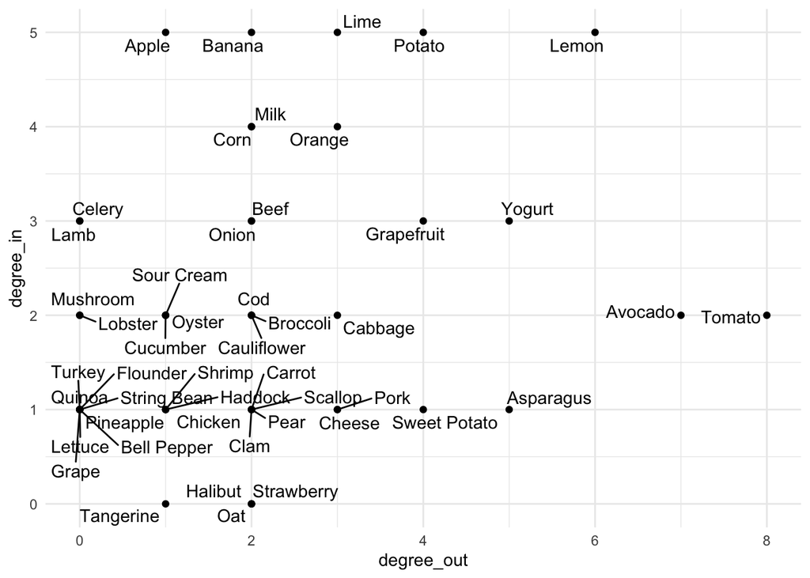

```r
node %>%
  filter(component %in% c(1)) %>%
  ggplot() +
    geom_point(aes(x = degree_out, y = degree_in)) +
    geom_text_repel(aes(x = degree_out, y = degree_in, label = id))
```

This shows that some pages from our last analysis, such as “Tomato”, are primarily central because they link to many other pages. In comparison, other central pages such as “Lime” and “Apple” are mostly connected by links into the pages.

## Cocitation Network

The graph structure we have been working with is a form of graph called a “citation network”. Pages are join whenever one links to another. This is a popular method in understanding academic articles, friendship networks on social media (i.e., tracking mentions on Twitter), or investigating the relative importance of court cases. There are some drawbacks of using citation counts, however. They are sensistive to the time-order of publication, they are effected by the relative length of each document, and they are easily effected by small changes. For example, we above saw the large effect that one sentence about stir-fry dishes on the “Asparagus” page had in increasing that page’s overall centrality score.

A co-citation network is a method of showing links across a citation network while avoiding some of the pitfalls that arise when using direct links. A co-citation is formed between two pages whenever a third entry cites *both* of them. The idea is that if a third source talks about two sources in the same reference, there is likely a relationship between the documents.

We created a co-citation dataset from Wikipedia by first downloading all of the pages linked to from any food pages in our collection. We then counted how often any pair of pages in our dataset were both linked to from the same source. The dataset is available here; duplicate rows were not removed, but the `page1` and `page2` were sorted so that `page1` always comes alphabetically before `page2`.

```r
page_cocitation <- read_csv(file.path("data", "page_cocitation.csv"))
page_cocitation
```

```
## # A tibble: 2,051 x 2
##    page1       page2
##    <chr>       <chr>
##  1 Broccoli    Kiwi
##  2 Bell Pepper Kiwi
##  3 Bell Pepper Broccoli
##  4 Kiwi        Strawberry
##  5 Broccoli    Strawberry
##  6 Bell Pepper Strawberry
##  7 Lemon       Strawberry
##  8 Kiwi        Lemon
##  9 Broccoli    Lemon
## 10 Bell Pepper Lemon
## # … with 2,041 more rows
```

Counting the number of times each pair occurs can be done by grouping the table and using the `sm_count` summary function.

```r
page_cocitation %>%
  group_by(page1, page2) %>%
  summarize(sm_count())
```

```
## # A tibble: 903 x 3
## # Groups:   page1 [58]
##    page1 page2       count
##    <chr> <chr>       <int>
##  1 Apple Asparagus       2
##  2 Apple Avocado         2
##  3 Apple Banana          6
##  4 Apple Beef            4
##  5 Apple Bell Pepper     3
##  6 Apple Broccoli        2
##  7 Apple Cabbage         4
##  8 Apple Carrot          2
##  9 Apple Cauliflower     1
## 10 Apple Cheese          2
## # … with 893 more rows
```

When working with co-citations, it is useful to only include links between two pages when the count is above some threshold. Here, we use a cut-off of 6 pages. Notice that co-citations are fundamentally undirected relationships.

```r
graph <- page_cocitation %>%
  group_by(page1, page2) %>%
  summarize(sm_count()) %>%
  filter(count >= 6) %>%
  sm_graph_layout()

node <- graph$node
edge <- graph$edge
```

Plotting the graph, we see that there is a very different structure compared to the citation plot.

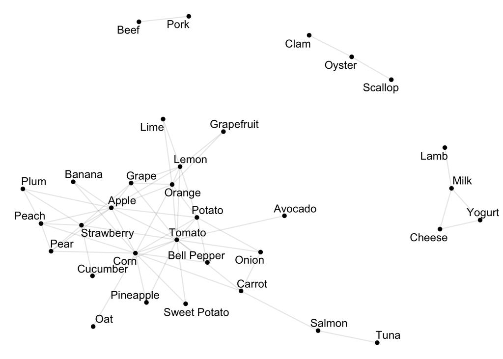

```r
node %>%
  ggplot(aes(x, y)) +
    geom_point() +
    geom_segment(aes(xend = xend, yend = yend), data = edge, alpha = 0.1) +
    geom_text_repel(aes(label = id)) +
    theme_void()
```

In the largest component, there are more links and less clustering across types of foods. The exercies include more examples to try to become familiar with the structure of these co-citation networks and how they tend to differ from citation networks.

## Distance Network

```r
token <- read_rds("cache/tokens.rds")
edges <- token %>%
  cnlp_utils_tfidf(token_var = "lemma") %>%
  sm_tidy_angle_distance()  %>%
  filter(document1 != document2) %>%
  group_by(document1) %>%
  arrange(distance) %>%
  slice_head(n = 3) %>%
  select(document1, document2)
```

A final type of network that we will explore here is a distance network. We start by computing the angle distance between the term-frequency scores for the text contained on each food’s Wikipedia page (see chapter 11). We then select edges by taking the closest 100 pairs of pages based on the texts.

```r
edges <- token %>%
  cnlp_utils_tfidf(token_var = "lemma") %>%
  sm_tidy_angle_distance()  %>%
  filter(document1 != document2) %>%
  arrange(distance) %>%
  slice_head(n = 100) %>%
  select(document1, document2)
```

Using these edges, we can create a graph network. As with co-citations, it would not make sense to use a directed network for the distance-based graph.

```r
graph <- sm_graph_layout(edges)
node <- graph$node
edge <- graph$edge
```

Looking at the clusters formed by the distance graph shows a grouping of the foods that very closely matches our understanding of the food types:

```r
node %>%
  group_by(cluster) %>%
  summarize(sm_paste(id))
```

```
## # A tibble: 9 x 2
##   cluster id_paste
##   <chr>   <fct>
## 1 1       Pear; Peach; Plum; Pineapple; Avocado; Strawberry; Apple; Kiwi
## 2 2       Quinoa; Corn; Oat; Chickpea
## 3 3       Haddock; Cod; Swordfish; Tuna; Salmon; Halibut; Shrimp
## 4 4       Tangerine; Orange; Grapefruit
## 5 5       Scallop; Lobster; Clam; Oyster
## 6 6       Lettuce; Carrot; Celery
## 7 7       Potato; Sweet Potato
## 8 8       Yogurt; Milk; Sour Cream
## 9 9       Cauliflower; Broccoli; Cabbage
```

Plotting the network shows that the structure is, again, different than the citation and co-citation networks. Rather than one large dominant component, there are several smaller, but tightly connected, components.

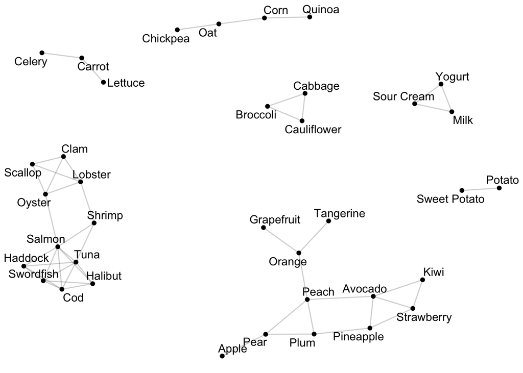

```r
node %>%
  ggplot(aes(x, y)) +
    geom_point() +
    geom_segment(aes(xend = xend, yend = yend), data = edge, alpha = 0.1) +
    geom_text_repel(aes(label = id)) +
    theme_void()
```

After axploring many examples of citation, co-citation, and distance networks, the typically patterns of each will become clear. Often the structure of a large network becomes apparent only after looking at several different versions of possible graphs.